# A Data Analysis Project in R

Bernardo Di Chiara

November 30, 2017

## 1. Introduction

This study uses publicly available data to create a research question for which first some exploratory data analysis is done and then inferential statistics is performed to verify if the possible correlations that have been found are statistically relevant. The file has been produced by using RStudio.

## 2. Setup

### 2.1. Load packages

Let’s load few R packages we will use in this project:

```r
library(ggplot2)
library(dplyr)
library(statsr)
```

### 2.2. Load data

Let’s load the data file:

```r
load("gss.Rdata")
```

## 3. Data

The Data used in this project is provided by the **General Social Survey (GSS)**, which has the purpose of gathering data on contemporary American society in order to monitor and explain trends and constants in attitudes and behaviors.

The Data has been collected through the years from 1972 to 2012. The survey has been repeated all together for 29 years during this interval. There are a total of 57,061 entries corresponding each to a different response.

The used **data collection method** is face-to-face interviews. Between 1972-2000, the survey was administered in a paper-and-pencil format, but starting in 2002, the GSS was conducted by computer-assisted personal interviewing (CAPI).

The **target population** is English-speaking persons 18 years of age or over, living in households within the United States. Starting in 2006 Spanish-speakers were added to the target population.

### 3.1. Consideration about Generabizability and Causality

The **sampling technique** consisted in random sampling (source: Wikipedia) even though the details about the used technique have been varying over the years. This ensures we can generalize the results to the entire target population.

However, before generalizing the results to the entire US population, we have to note the following issues.

- The survey includes only the English speaking community (also the Spanish speaking community since year 2006). It is estimated that the percentage of population left out due to this reason is around a couple of percents.
- The survey does not include people leaving in institutional arrangements like students’ colleges, military quarters and nursing homes. The percentage of population left out from the survey results due to this reason varies with the age group and is estimated to be overall around few percents.

Each year an independently drawn sample was used. This ensures that samples in different years are independent from each other.

Due to the **observational nature of the survey**, it is only possible to find associations between different variables but it is not possible to deduce any causal relationship.

## 4. Research Question

> Is there any difference in the perception of the importance of job security between year 2006 and year 2012 among the adult population in the United States?

Understanding what affect employees’ motivation is very important for companies in order to attract and detain the best talents. Those motivations might vary over time.

In this study we are investigating what are the things motivating most at work. In particular we will focus on job security. We will analyse the data from 2006 and from 2012 and investigate whether there have been any sensible differences.

Due to the increasing volatile job market, concerns about job security might have grown over this interval of 6 years.

## 5. Exploratory Data Analysis (EDA)

### 5.1. Selecting the Variables, Investigating the Variable Types, Rearranging and Cleaning the Data

Since we are interested only in data from 2006 and 2012, we **create a new dataframe** containing only data from those years.

```r
# Creating a dataframe containing only data from years 2006 and 20012
gss0612clean <- gss %>%
  filter(year %in% c(2006,2012))
# Quering about the number of entries in the new dataframe
dim(gss0612clean)
```

```
## [1] 6484  114
```

We have all together 6484 entries. We have more entries for year 2006 compared to 2012, as shown below.

```r
# Checking the number of entries in each year
gss0612clean %>%
  group_by(year) %>%
  summarise(count = n())
```

```
## # A tibble: 2 x 2
##    year count
##   <int> <int>
## 1  2006  4510
## 2  2012  1974
```

In addition to the variables `year` and `age`, we will use the variable `jobsec`, indicating how important job security (no danger to be fired) is for the respondent.

Let’s simplify the `gss0612clean` data frame by **elimitating all the variables we do not need**.

```r
gss0612clean <- gss0612clean %>%
# Removing unnecessary variables
  select(year, age, jobsec)
# Checking the variables' datatypes
str(gss0612clean)
```

```
## 'data.frame':    6484 obs. of  3 variables:
##  $ year  : int  2006 2006 2006 2006 2006 2006 2006 2006 2006 2006 ...
##  $ age   : int  50 27 67 50 20 35 29 32 23 32 ...
##  $ jobsec: Factor w/ 5 levels "Most Impt","Second",..: NA NA NA NA NA NA NA 4 NA NA ...
```

The variables `year` and `age` are numerical, the variable `jobsec` is categorical and has quite many entries with NA value, as shown below.

```r
# Summarizing the counts of each level of the variable jobsec
gss0612clean %>%
  group_by(jobsec)%>%
  summarise(count = n())
```

```
## # A tibble: 6 x 2
##   jobsec    count
##   <fct>     <int>
## 1 Most Impt   431
## 2 Second      374
## 3 Third       415
## 4 Fourth      649
## 5 Fifth       578
## 6 <NA>       4037
```

Let’s **remove those entries with NA value in `jobsec`**.

```r
gss0612clean <- gss0612clean %>%
# Removing jobsec entries which have NA values
  filter(!is.na(jobsec))
# Checking remaining entries (rows)
dim(gss0612clean)
```

```
## [1] 2447    3
```

```r
# Checking remaining entries for each year
gss0612clean %>%
  group_by(year) %>%
  summarise(count = n())
```

```
## # A tibble: 2 x 2
##    year count
##   <int> <int>
## 1  2006  1498
## 2  2012   949
```

We have 2447 entries left. Of those only 949 are 2012 data, the remaining 1498 are 2006 data.

Let’s **convert the variable `year` into a categorical variable**.

```r
gss0612clean <- gss0612clean %>%
  # Changing year into a categorical variable
  mutate(year = as.factor(year))
str(gss0612clean)
```

```
## 'data.frame':    2447 obs. of  3 variables:
##  $ year  : Factor w/ 2 levels "2006","2012": 1 1 1 1 1 1 1 1 1 1 ...
##  $ age   : int  32 37 24 41 35 26 35 30 57 65 ...
##  $ jobsec: Factor w/ 5 levels "Most Impt","Second",..: 4 5 3 2 4 5 1 4 3 2 ...
```

Let’s **create other two dataframes in order to separate the data of the two years**.

```r
# Data from 2006
gss06clean <- gss0612clean %>%
  filter(year == 2006)
```

```r
#Data from 2012
gss12clean <- gss0612clean %>%
  filter(year == 2012)
```

Finally, we want to **create a new categorical variable describing the age group**. In order to do that, let’s first check if there are any NA values in this variable.

```r
# Investigating possible NA values in the variable age
gss0612clean %>%
  filter(is.na(age))
```

```
##    year age    jobsec
## 1  2006  NA    Fourth
## 2  2006  NA    Second
## 3  2006  NA    Second
## 4  2006  NA     Fifth
## 5  2006  NA     Fifth
## 6  2006  NA Most Impt
## 7  2006  NA    Second
## 8  2006  NA     Fifth
## 9  2006  NA    Fourth
## 10 2012  NA     Fifth
## 11 2012  NA Most Impt
```

As shown above, there are 11 of such values. It is not a huge number but we still want to use those entries in the research. So we create a new data frame where we remove such values and we will use this data frame only when we have to do some analysis that involves the new age group variable. Then, we check the extreme values of the variable `age` and, based on this result, we create the new categorical variable `agegroup` which has three levels:

- “Young” (from 18 to 35 years old)
- “Middle-age” (from 36 to 50 years old)
- “Senior” (from 51 years old to older)

```r
gss0612clean2 <- gss0612clean %>%
  # Removing age entries which have NA values
  filter(!is.na(age))
str(gss0612clean2)
```

```
## 'data.frame':    2436 obs. of  3 variables:
##  $ year  : Factor w/ 2 levels "2006","2012": 1 1 1 1 1 1 1 1 1 1 ...
##  $ age   : int  32 37 24 41 35 26 35 30 57 65 ...
##  $ jobsec: Factor w/ 5 levels "Most Impt","Second",..: 4 5 3 2 4 5 1 4 3 2 ...
```

```r
# Checking minimum and maximum age
gss0612clean2 %>%
  summarise (agemin = min(age), agemax = max(age), sample_size = n())
```

```
##   agemin agemax sample_size
## 1     18     89        2436
```

```r
gss0612clean2 <- gss0612clean2 %>%
  # Adding the agegroup categorical variable (the defined interval are closed to the right and include the lowest value)
  mutate (agegroup = cut (age, breaks=c(18, 35, 50, 89), right=TRUE, include.lowest=TRUE, labels=c("Young", "Middle-age", "Senior")))
str(gss0612clean2)
```

```
## 'data.frame':    2436 obs. of  4 variables:
##  $ year    : Factor w/ 2 levels "2006","2012": 1 1 1 1 1 1 1 1 1 1 ...
##  $ age     : int  32 37 24 41 35 26 35 30 57 65 ...
##  $ jobsec  : Factor w/ 5 levels "Most Impt","Second",..: 4 5 3 2 4 5 1 4 3 2 ...
##  $ agegroup: Factor w/ 3 levels "Young","Middle-age",..: 1 2 1 2 1 1 1 1 3 3 ...
```

### 5.2. Plots and Statistics

First, we plot both year 2006 and year 2012 results by using the `gss0612clean` data frame. Then, we create a table to calculate the proportions given to each option (related to the importance of job security) by using the two data frames which contain only data related to each year.

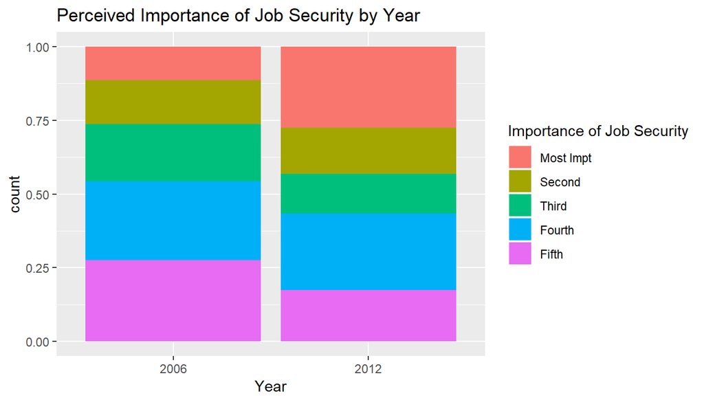

```r
# Plotting the importance of job security for the years 2006 and 2012
ggplot(data = gss0612clean, aes(x = factor(year), fill = jobsec)) +
  geom_bar(position="fill") + xlab("Year") + scale_fill_discrete(name="Importance of Job Security") + ggtitle("Perceived Importance of Job Security by Year")
```

```r
# Creating a counts table for the importance of job security in 2006
jobsec06 = table(gss06clean$jobsec)
jobsec06
```

```
##
## Most Impt    Second     Third    Fourth     Fifth
##       170       225       288       403       412
```

```r
# Creating a proportion table for the importance of job security in 2006
jobsec06p <- prop.table(jobsec06)
jobsec06p
```

```
##
## Most Impt    Second     Third    Fourth     Fifth
## 0.1134846 0.1502003 0.1922563 0.2690254 0.2750334
```

```r
# Creating a counts table for the importance of job security in 2012
jobsec12 = table(gss12clean$jobsec)
jobsec12
```

```
##
## Most Impt    Second     Third    Fourth     Fifth
##       261       149       127       246       166
```

```r
# Creating a proportion table for the importance of job security in 2012
jobsec12p <- prop.table(jobsec12)
jobsec12p
```

```
##
## Most Impt    Second     Third    Fourth     Fifth
## 0.2750263 0.1570074 0.1338251 0.2592202 0.1749210
```

The diagram above shows a higher percentage of people who consider job security the most important thing and a lower percentage of people who consider it the last important thing in 2012 compared to 2006. This is confirmed by the statistics calculated above, which show that the percentage of people who consider job security the most important thing in 2012 is 27.5% compared to 11.3% in 2006.

Now let’s draw the same diagram by differentiating by age group. Note that the data used for this second diagram is slightly different since we have eliminated 11 entries.

```r
# Checking responses distribution across the age group
gss0612clean2  %>%
  group_by(agegroup) %>%
  summarise(count = n())
```

```
## # A tibble: 3 x 2
##   agegroup   count
##   <fct>      <int>
## 1 Young        712
## 2 Middle-age   789
## 3 Senior       935
```

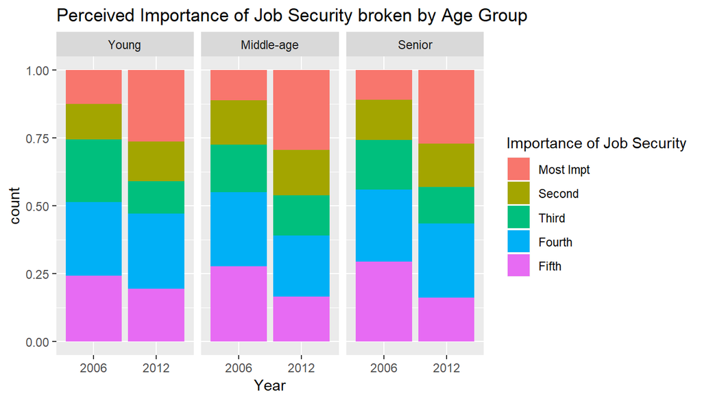

```r
# Plotting the importance of job security for the years 2006 and 2012, broken by age group
ggplot(data = gss0612clean2, aes(x = factor(year), fill = jobsec)) + facet_grid(.~agegroup) + geom_bar(position="fill") + xlab("Year") + scale_fill_discrete(name="Importance of Job Security") + ggtitle("Perceived Importance of Job Security broken by Age Group")
```

The trend seems consistent with what seen in the first diagram and consistent across all the age groups.

### 5.3. Results

*There is an association between the year of the survey (2006/2012) and the perception of the importance of job security which shows a trend towards an increasing concern for job security. This trend is consistent across all age groups.*

## 6. Inference

Now we want to investigate if the difference in proportions of people that consider job security an important issue between year 2006 and year 2012 is statistically relevant.

### 6.1. Hypothesis

We will do a hypothesis test.

Our null condition H<sub>0</sub> and alternate condition H<sub>A</sub> are stated below.

**H<sub>0</sub>:** The perceived importance of job satisfaction did not change from 2006 to 2012 (any observed difference is due to chance)

**H<sub>A</sub>:** The perceived importance of job satisfaction changed from 2006 to 2012

We will check scientifically if we can reject the null hypothesis.

### 6.2. Used Method and Checking the Conditions

The variable of interest is a categorical variable with more than two levels `jobsec`. So we will use a chi-squared test for goodness of fit.

The conditions for applying this type of test are satisfied:

- **Independence.** Each case that contributes to a count is independent from all the others. This is ensured by the random sampling technique utilized to collect the data. Also, each year an independently drawn sample was used, ensuring that the 2006 data are not paired with the 2012 data. The sample is definitely below 10% of the entire population.
- **Sample size.** Each particular scenario has more than 5 cases (see tables `jobsec06` and `jobsec12`). Therefore, we can use a theoretical method.

The chi-squared test statistic consists in investigating how far the observed counts are from the expected counts. A larger chi-squared values produce lower p-values and greater evidence against the null hypothesis. There is no associated confidence interval with this method.

### 6.3. Preparing the Data

The counts of people who selected each option in year 2012 is given by the table `jobsec12` created above. The table contains are our **observed frequencies**

```r
#Observed frequencies
jobsec12
```

```
##
## Most Impt    Second     Third    Fourth     Fifth
##       261       149       127       246       166
```

If the perceived importance of job satisfaction would stay constant in 2012, we would expect that 2012 answers would look like shown in the table below, where we have multiplied each element of the table `jobsec06p` (giving the proportions given to each answer in 2006, that is, the **expected proportions**) by the number of responses in 2012 (949).

```r
# Expected frequencies
jobsec12E <- jobsec06p*949
jobsec12E
```

```
##
## Most Impt    Second     Third    Fourth     Fifth
##  107.6969  142.5401  182.4513  255.3051  261.0067
```

The above table contains the **expected frequencies**.

### 6.4. Performing Inference and Interpreting the Results

The X-squared is calculated below, together with the degrees of freedom and the p-value by using the observed frequencies and the expected proportions.

```r
# Calculating X-squared, df and p-value
chisq.test(x = jobsec12, p = jobsec06p)
```

```
##
##  Chi-squared test for given probabilities
##
## data:  jobsec12
## X-squared = 270.29, df = 4, p-value < 2.2e-16
```

As expected, the degree of freedom is the number of level k (in this case 5) minus 1.

The X-squared value is quite high and as a consequence the p-value is very low. Therefore, we reject the null hypothesis and conclude that *there is significant evidence that the perceived importance of job satisfaction changed from 2006 to 2012*.

### 6.5. Further Investigation

By looking at the bar plots in section 5.2, it appears that the biggest difference in proportions between the two years is among those who consider job security the most important issue among all.

We want to do a second hypothesis test to verify that this difference in proportions is statistically significant.

### 6.5.1. Hypothesis

Let’s call:

- p<sub>06</sub> the proportion of those who consider job security top priority in 2006
- p<sub>12</sub> the proportion of those who consider job security top priority in 2012

**H<sub>0</sub>:** p<sub>06</sub>-p<sub>12</sub>=0

**H<sub>A</sub>:** p<sub>06</sub>-p<sub>12</sub>≠0

### 6.5.2. Used Method

We will do a hypothesis test related to the difference of two proportions. We will calculate the test statistics as a difference between a point estimate (p<sub>12</sub>^-p<sub>06</sub>^) and the null value (which is 0 in this case) divided by the standard error of the point estimate (SE).

We will use the pooled proportion estimate (p^) for checking that the conditions are verified and to calculate the standard error. n<sub>06</sub> is the number of respondents in 2006 and n<sub>12</sub> is the number of the respondents in 2012 (n<sub>x</sub> is the sample size).

Based on the obtained value of the test statistics we will calculate the p-value that will give an indication whether to reject or not the null hypothesis. A small p-value indicates that the probability to get the point estimate under the condition that the null hypothesis is true is quite small and therefore it provides evidence against the null hypothesis.

We will do most of those tasks by using R inference function.

### 6.5.3. Checking the Conditions

Let’s calculate the pooled proportion.

```r
#Calculating the pooled proportion
phat=(0.1134846*1498+0.2750263*949)/(1498+949)
print(phat)
```

```
## [1] 0.176134
```

Conditions:

- Both the 2016 and the 2012 samples observations are independent due to random sampling
- The success-failure condition is verified for the 2006 sample (n<sub>06</sub>*p^ = 263.9)
- The success-failure condition is verified for the 2012 sample (n<sub>12</sub>*p^ = 167.2)
- The two samples are independent from each other (since, as we observed above, each year an independently drawn sample was used)

Therefore, we can apply the method we have described above.

### 6.5.4. Preparing the Data

In order to proceed, we need to add a new variable to the `gss0612clean` dataframe indicating if the respondent considers job security top priority.

```r
# Adding a new variable in the gss0612clean dataframe indicating if the respondent considers job security top priority
gss0612clean <- gss0612clean %>%
  mutate(pjobsecuritytop = ifelse(jobsec == "Most Impt", "Top Prio", "Not Top Prio")) %>%
# Giving to this variable a factor datatype
  mutate (pjobsecuritytop = as.factor(pjobsecuritytop))
str(gss0612clean)
```

```
## 'data.frame':    2447 obs. of  4 variables:
##  $ year           : Factor w/ 2 levels "2006","2012": 1 1 1 1 1 1 1 1 1 1 ...
##  $ age            : int  32 37 24 41 35 26 35 30 57 65 ...
##  $ jobsec         : Factor w/ 5 levels "Most Impt","Second",..: 4 5 3 2 4 5 1 4 3 2 ...
##  $ pjobsecuritytop: Factor w/ 2 levels "Not Top Prio",..: 1 1 1 1 1 1 2 1 1 1 ...
```

### 6.5.5. Performing Inference and Interpretation of the Results

The explanatory variable is the year. The response variable is the proportion of those who consider job security top priority.

We perform another hypothesis test.

```r
# Hypothesis test where H0 is that the proportion of those who consider job security top priority has not changed between year 2006 and year 2012 and Ha is that the proportion has changed
inference(y = pjobsecuritytop, x = year, data = gss0612clean, statistic = "proportion", type = "ht", method = "theoretical", order = 2012, success = "Top Prio", null = 0, alternative = "twosided", sig_level = 0.05)
```

```
## Response variable: categorical (2 levels, success: Top Prio)
## Explanatory variable: categorical (2 levels)
## n_2012 = 949, p_hat_2012 = 0.275
## n_2006 = 1498, p_hat_2006 = 0.1135
## H0: p_2012 =  p_2006
## HA: p_2012 != p_2006
## z = 10.2213
## p_value = < 0.0001
```

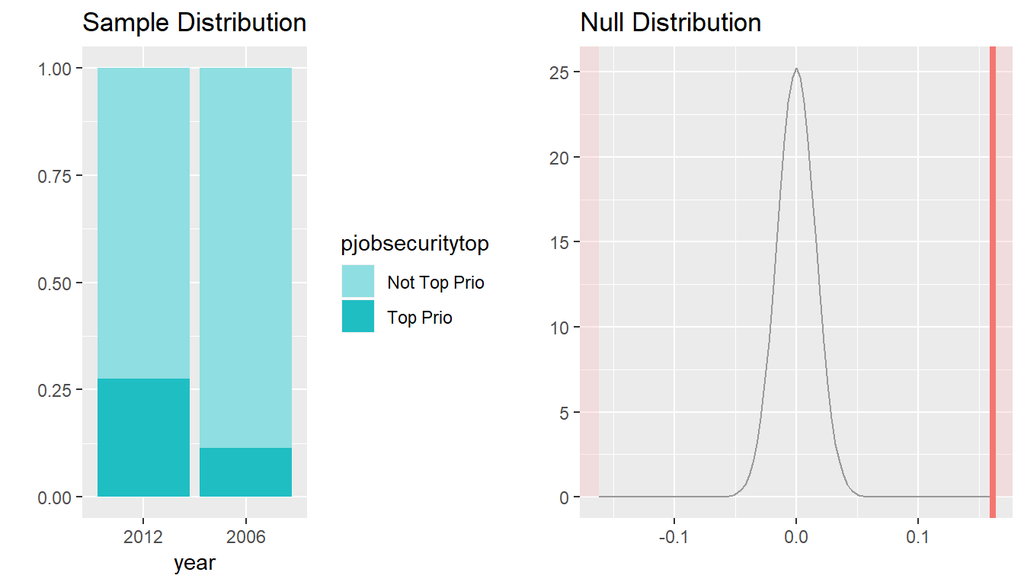

```r
# The parameter "order" tells to calculate the difference as p12-p06
```

The p-value is smaller than 0.0001, which is less than the significance level of 0.05. Therefore, we reject the null hypothesis and we conclude that *there is significant evidence that there is a difference between year 2012 and year 2006 in the proportion of those who perceive job security as top priority and this difference is positive*.

### 6.5.6. Verification

Finally, we verify the results obtained above by calculating a 95% confidence interval for the difference in proportions. The conditions for applying this method are verified as shows below.

- Both the 2016 and the 2012 samples observations are independent due to random sampling
- The success-failure condition is verified for the 2006 sample (n<sub>06</sub>*p<sub>06</sub> = 170 ≧10)
- The success-failure condition is verified for the 2012 sample (n<sub>12</sub>*p<sub>12</sub> = 261 ≧10)
- The two samples are independent from each other (since, as we observed above, each year an independently drawn sample was used)

Also in this case we will use the inference function in R to do the actual calculation and getting the diagrams.

```r
# Confidence interval for the difference in proportions of those who consider job security top priority between year 2006 and year 2012
inference(y = pjobsecuritytop, x = year, data = gss0612clean, statistic = "proportion", type = "ci", method = "theoretical", order = 2012, success = "Top Prio", conf_level = 0.95)
```

```
## Response variable: categorical (2 levels, success: Top Prio)
## Explanatory variable: categorical (2 levels)
## n_2012 = 949, p_hat_2012 = 0.275
## n_2006 = 1498, p_hat_2006 = 0.1135
## 95% CI (2012 - 2006): (0.1289 , 0.1942)
```

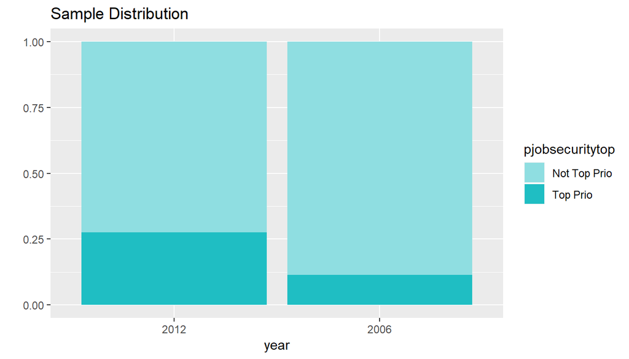

The confidence interval is between 0.1289 and 0.1942. Both values are positive, as expected from the exploratory data analysis since the difference has been calculated as p<sub>12</sub>-p<sub>06</sub>. *We are 95% confident that the difference in proportions between those who consider job security top priority in 2012 and those who consider job security top priority in 2006 is between 0.1289 and 0.1942.*

The interval does not include the zero, which is the null value. This confirms that we have to reject the null hypothesis H<sub>0</sub>: p<sub>06</sub>-p<sub>12</sub>=0

## 7. Conclusion

By performing exploratory data analysis we have discovered that the percentage of people who consider job security the most important thing in 2012 is higher compared to 2006 and the percentage of people who consider job security the last important thing is lower in 2012 compared to 2006. This shows a trend towards an increasing concern for job security and this trend is consistent across all the age groups.

By using inference methods we have found that those differences are statistically relevant. In other words, there is significant evidence that the perceived importance of job satisfaction changed from 2006 to 2012. By doing a more detailed analysis we have confirmed that there is significant evidence that there is a difference between year 2012 and year 2006 in the proportion of those who perceive job security as top priority and this difference is positive.

The target of the study was English- or Spanish-speaking adults, living in households in the United States. Before generalizing those results to the entire US population, it should be noted that few percents of the US population are either speaking another language and/or living in institutional arrangements.

It is also worth to note that, due to the observational nature of the study, no cause-effect conclusions can be deduced by these findings.

<sub>R version 3.4.1 on Windows 10</sub>